# Project 1 SPOOKY text analysis

Minzi Keem

2/5/2018

# Section 0: check and install necessary packages, load the libraries and the functions.

## Setup the libraries

```r
packages.used <- c("ggplot2", "dplyr", "tibble", "tidyr",  "stringr", "tidytext", "topicmodels", "wordcloud", "ggridges", "igraph", "ggraph", "forcats")

# check packages that need to be installed.
packages.needed <- setdiff(packages.used, intersect(installed.packages()[,1], packages.used))

# install additional packages
if(length(packages.needed) > 0) {
  install.packages(packages.needed, dependencies = TRUE, repos = 'http://cran.us.r-project.org')
}

library(ggplot2)
library(dplyr)
library(tibble)
library(tidyr)
library(stringr)
library(tidytext)
library(topicmodels)
library(wordcloud)
library(ggridges)
library(igraph)
library(ggraph)
library(forcats)

source("../libs/multiplot.R")
```

## Read in the data

```r
spooky <- read.csv('../data/spooky.csv', as.is = TRUE)
```

## An overview of the data structure and content

Let’s first remind ourselves of the structure of the data.

```r
head(spooky)
```

[output not shown]

```r
summary(spooky)
```

```
##       id                text              author
##  Length:19579       Length:19579       Length:19579
##  Class :character   Class :character   Class :character
##  Mode  :character   Mode  :character   Mode  :character
```

We have id numbers for all the text lines, then the text, then a three letter character indicating the author.

# Section 1: Data cleaning

We first use the `unnest_tokens()` function to drop all punctuation and transform all words into lower case from the `tidytext` package. `tidytext` also contains stop words that we will eliminate.

```r
# Makes a table with one word per row and remove `stop words` (i.e. the common words).
spooky_wrd <- unnest_tokens(spooky, word, text)
spooky_wrd <- anti_join(spooky_wrd, stop_words, by = "word")
```

# Section 2: Word Frequency

## Wordcloud - all

We check to see the word frequency for the fifty most common words, and visualize them in a wordcloud.

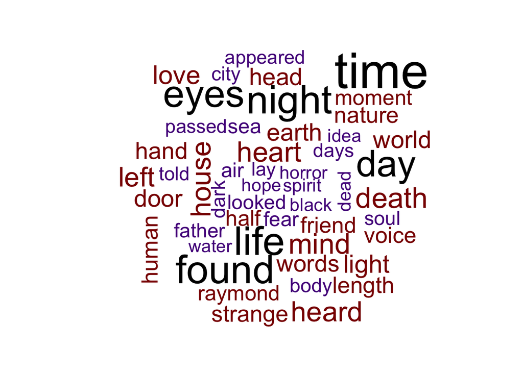

```r
# Words is a list of words, and freqs their frequencies
words <- count(group_by(spooky_wrd, word))$word
freqs <- count(group_by(spooky_wrd, word))$n

#png("../figs/Worldcloud_all.png")
wordcloud(words, freqs, max.words = 50, color = c("purple4", "red4", "black"))
```

```r
#dev.off()
```

This wordcloud shows that “time”, “night”, “found”, “life”, “day” and “eyes” appear often between all of the texts.

## Wordcloud - separated by author

We check to see the word frequency for the fifty most common words, separated by author. First, for Edgar Allen Poe, then HP Lovecraft, then Mary Shelley.

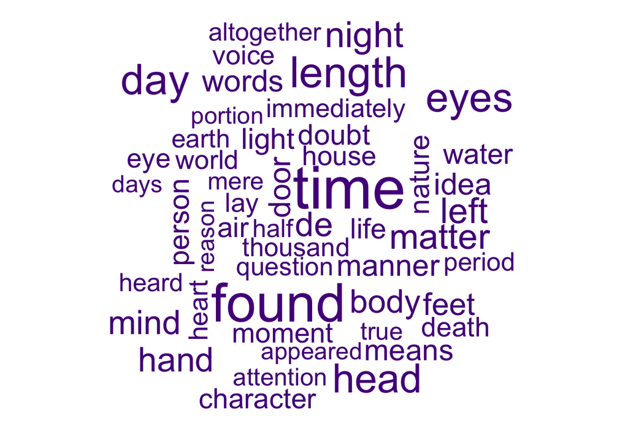

```r
#EAP
# Words is a list of words, and freqs their frequencies
EAP <- filter(spooky_wrd, author == "EAP")
words <- count(group_by(EAP, word))$word
freqs <- count(group_by(EAP, word))$n

#png("../figs/Worldcloud_EAP.png")
wordcloud(words, freqs, max.words = 50, color = c("purple4"))
```

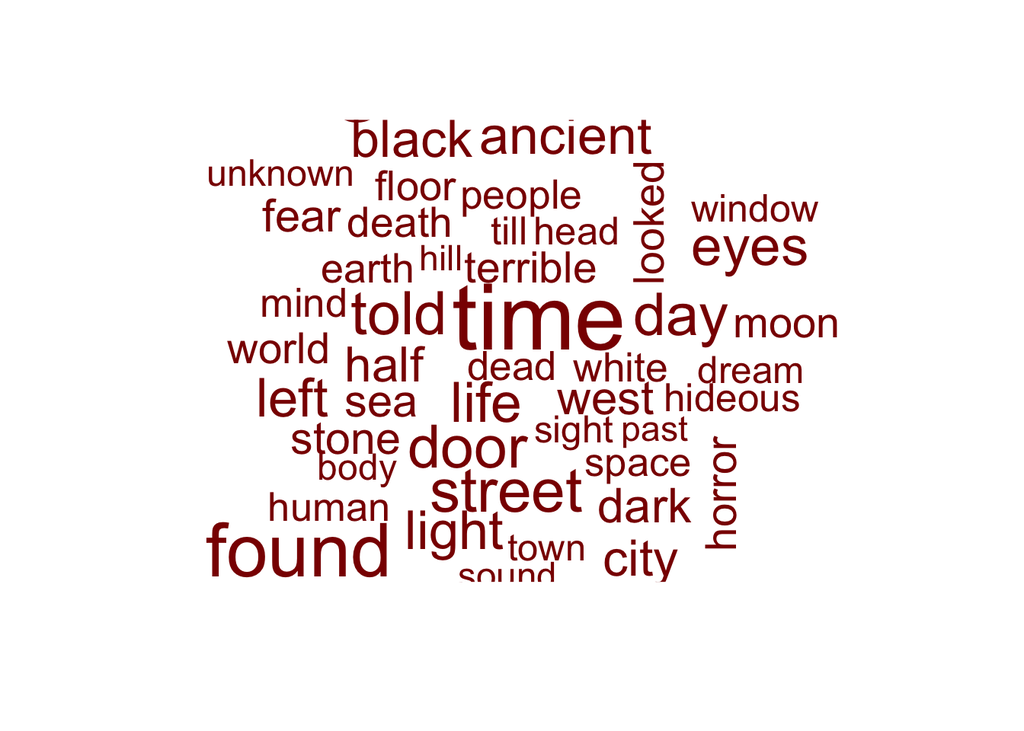

```r
#dev.off()

#HPL
# Words is a list of words, and freqs their frequencies
HPL <- filter(spooky_wrd, author == "HPL")
words <- count(group_by(HPL, word))$word
freqs <- count(group_by(HPL, word))$n

#png("../figs/Worldcloud_HPL.png")
wordcloud(words, freqs, max.words = 50, color = c("red4"))
```

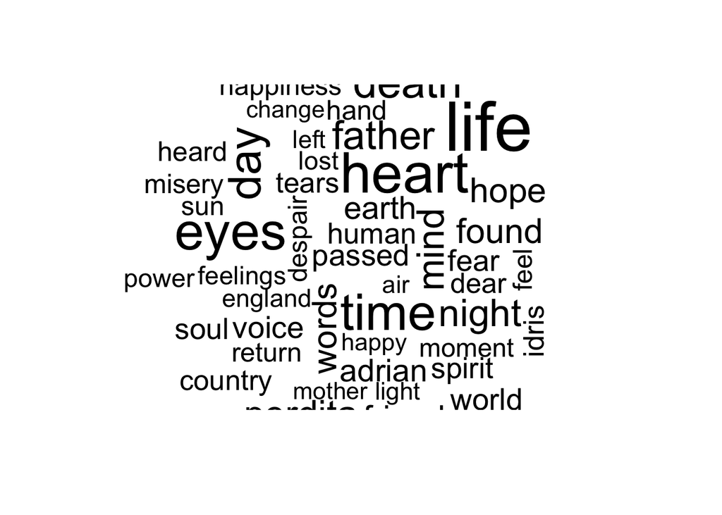

```r
#dev.off()

#MWS
# Words is a list of words, and freqs their frequencies
MWS <- filter(spooky_wrd, author == "MWS")
words <- count(group_by(MWS, word))$word
freqs <- count(group_by(MWS, word))$n

#png("../figs/Worldcloud_MWS.png")
wordcloud(words, freqs, max.words = 50, color = c("black"))
```

```r
#dev.off()
```

I personally don’t like seeing warning signs, which is why I put include = FALSE, but all of the figures end up generating in the figs folder.

# Section 3: Bigrams

```r
temp <- select(spooky, author, text)
temp <- unnest_tokens(temp, bigram, text, token = "ngrams", n = 2)

#separate the bigrams and attach them again
bigram_sep <- separate(temp, bigram, c("word1", "word2"), sep = " ")
temp2 <- filter(bigram_sep, !word1 %in% stop_words$word)
temp2 <- filter(temp2, !word2 %in% stop_words$word)

#attach back together after removing stop words
temp <- unite(temp2, bigram, word1, word2, sep = " ")

#extract tf-idf values
temp3 <- count(temp, author, bigram)
temp3 <- bind_tf_idf(temp3, bigram, author, n)
test_tf_idf <- arrange(temp3, desc(tf_idf))
```

## Graphically represent results

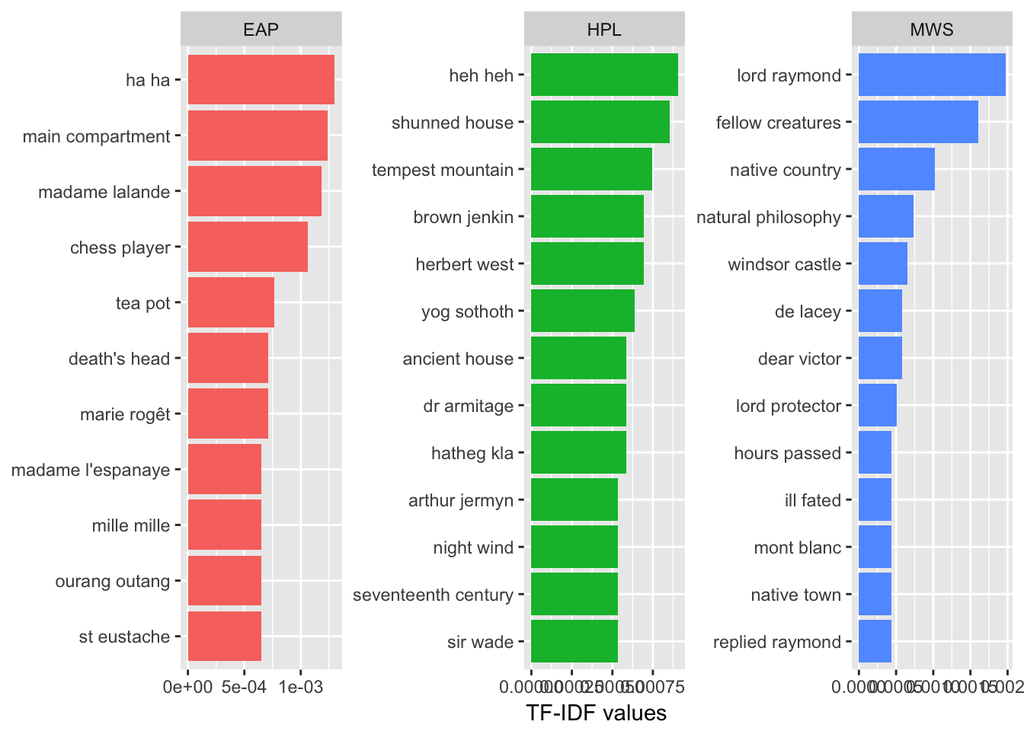

```r
a <- arrange(test_tf_idf, desc(tf_idf))
a <- mutate(a, bigram = factor(bigram, levels = rev(unique(bigram))))
a <- group_by(a, author)
a <- top_n(a, 10, tf_idf)
a <- ungroup(a)

#graph
ggplot(a, aes(bigram, tf_idf, fill = author)) + geom_col() + labs(x = NULL, y = "TF-IDF values") +
  theme(legend.position = "none") + facet_wrap(~ author, ncol = 3, scales = "free") + coord_flip()
```

```r
ggsave("Bigram_tf-idf.png", plot = last_plot(), device = "png", path = "../figs/")
```

Again, these figures generate in the figs folder. Analysis of these figures are in the main readme.

## Networks of bigrams

We use the igraph and ggraph packages to help us visualive the network.

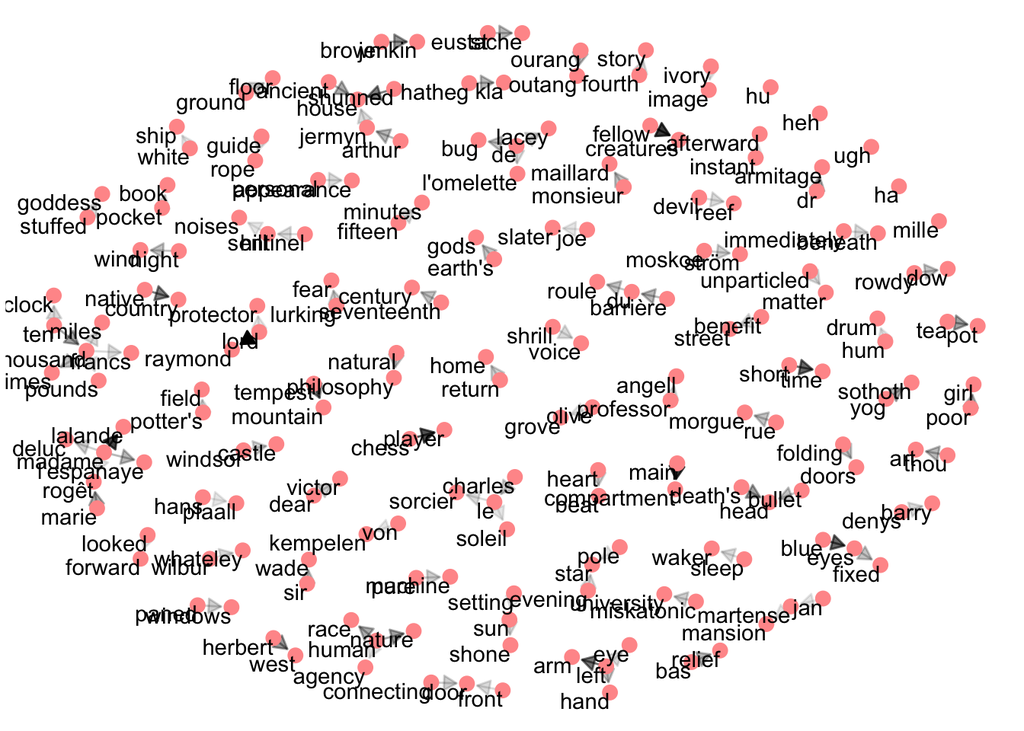

```r
bigram_counts <- count(temp2, word1, word2, sort = TRUE)
b <- filter(bigram_counts, n > 6)
bigram_graph <- graph_from_data_frame(b)

set.seed(1234)

a <- grid::arrow(type = "closed", length = unit(.1, "inches"))

ggraph(bigram_graph, layout = "fr") +
  geom_edge_link(aes(edge_alpha = n), show.legend = FALSE,
                 arrow = a, end_cap = circle(.07, 'inches')) +
  geom_node_point(color = "#FF9999", size = 3) +
  geom_node_text(aes(label = name), vjust = 1, hjust = 1) +
  theme_void()
```

```r
ggsave("Bigram_network.png", plot = last_plot(), device = "png", path = "../figs/")
```

This figure generates in the figure folder, with the analysis in the readme.

# Section 4: Punctuations

```r
#count the number of commas, colons, quotation marks, semicolons, and question marks in the text for EAP
EAP_sentence <- filter(spooky, author == "EAP")
EAP_sentence$comma <- str_count(EAP_sentence$text, ',')
EAP_sentence$colon <- str_count(EAP_sentence$text, '[:]')
EAP_sentence$quot <- str_count(EAP_sentence$text, '["]')
EAP_sentence$semi <- str_count(EAP_sentence$text, ';')
EAP_sentence$question <- str_count(EAP_sentence$text, '[?]')

#count the number of commas, colons, quotation marks, semicolons, and question marks in the text for HPL
HPL_sentence <- filter(spooky, author == "HPL")
HPL_sentence$comma <- str_count(HPL_sentence$text, ',')
HPL_sentence$colon <- str_count(HPL_sentence$text, '[:]')
HPL_sentence$quot <- str_count(HPL_sentence$text, '["]')
HPL_sentence$semi <- str_count(HPL_sentence$text, ';')
HPL_sentence$question <- str_count(HPL_sentence$text, '[?]')

#count the number of commas, colons, quotation marks, semicolons, and question marks in the text for MWS
MWS_sentence <- filter(spooky, author == "MWS")
MWS_sentence$comma <- str_count(MWS_sentence$text, ',')
MWS_sentence$colon <- str_count(MWS_sentence$text, '[:]')
MWS_sentence$quot <- str_count(MWS_sentence$text, '["]')
MWS_sentence$semi <- str_count(MWS_sentence$text, ';')
MWS_sentence$question <- str_count(MWS_sentence$text, '[?]')
```

## Graphically represent our findings of punctuation counts

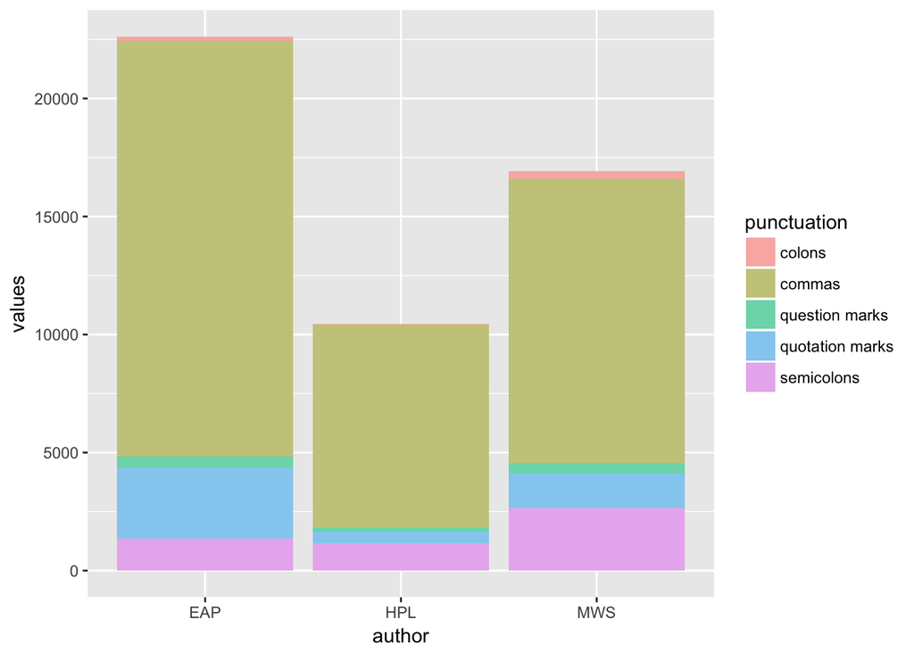

```r
#place the total counts for everything in a dataframe, to be graphed later
punctuation <- rep(c("commas", "colons", "quotation marks", "semicolons", "question marks"), 3)
p1 <- c(sum(EAP_sentence$comma), sum(EAP_sentence$colon), sum(EAP_sentence$quot), sum(EAP_sentence$semi), sum(EAP_sentence$question))
p2 <- c(sum(HPL_sentence$comma), sum(HPL_sentence$colon), sum(HPL_sentence$quot), sum(HPL_sentence$semi), sum(HPL_sentence$question))
p3 <- c(sum(MWS_sentence$comma), sum(MWS_sentence$colon), sum(MWS_sentence$quot), sum(MWS_sentence$semi), sum(MWS_sentence$question))
values <- c(p1, p2, p3)
author <- c(rep("EAP", 5), rep("HPL", 5), rep("MWS", 5))
df <- data.frame(punctuation, values, author)

#now we are graphing the punctuation count
p <- ggplot() + geom_bar(aes(y = values, x = author, fill = punctuation), data = df, stat="identity") +
    scale_fill_hue(c=45, l=80)
ggsave("Punctuation_Count.png", plot = last_plot(), device = "png", path = "../figs/")
p
```

## Graphically represent averages per sentence

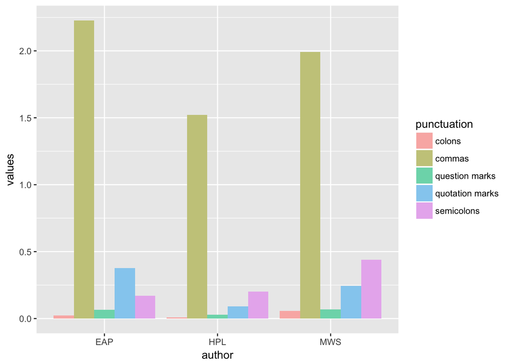

```r
#taking the averages of the things we found earlier
p1 <- p1/length(EAP_sentence$text)
p2 <- p2/length(HPL_sentence$text)
p3 <- p3/length(MWS_sentence$text)
values <- c(p1, p2, p3)
author <- c(rep("EAP", 5), rep("HPL", 5), rep("MWS", 5))
df <- data.frame(punctuation, values, author)

#graphically representing the averages, this time taking splitting the punctuations side by side.
p2 <- ggplot() + geom_bar(aes(y = values, x = author, fill = punctuation), data = df, stat="identity", position = "dodge") + scale_fill_hue(c=45, l=80)
ggsave("Punctuation_Averages.png", plot = last_plot(), device = "png", path = "../figs/")
p2
```

# Section 5: Gendered Words

We use the forcats package to help us with factoring the different words in the text and reordering things on the ggplot. Please note that in the last plot, the order of the genders are switched.

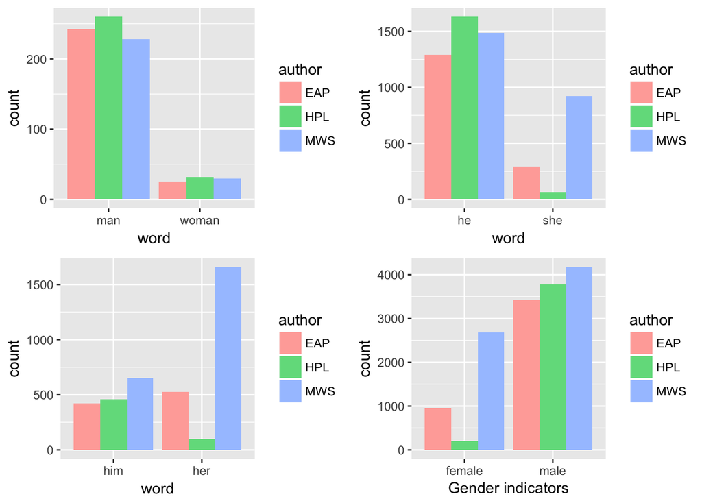

```r
#counting the number of "man" and "woman" in the text
a <- unnest_tokens(spooky, word, text)
a <- filter(a, (word == "man") | (word == "woman"))
a <- mutate(a, word = as.factor(word))
mwcomp <- ggplot(a, aes(word, fill = author)) + geom_bar(position = "dodge") + scale_fill_hue(c=70, l=80)

#counting the number of "he" and "she" in the text
b <- unnest_tokens(spooky, word, text)
b <- filter(b, (word == "he") | (word == "she"))
b <- mutate(b, word = as.factor(word))
heshe <- ggplot(b, aes(word, fill = author)) + geom_bar(position = "dodge") + scale_fill_hue(c=70, l=80)

#counting the number of "him" and "her" in the text
c <- unnest_tokens(spooky, word, text)
c <- filter(c, (word == "him") | (word == "her"))
c <- mutate(c, word = fct_relevel(word, "him", "her"))
himher <- ggplot(c, aes(word, fill = author)) + geom_bar(position = "dodge") + scale_fill_hue(c=70, l=80)

#counting a variety of different gendered words
d <- unnest_tokens(spooky, word, text)
d <- mutate(d, male = ( word == "he" | word == "him" | word == "his" | word == "male" |
                    word == "man" | word == "gentleman" | word == "sir" |
                    word == "lord" | word == "men" ))
d <- mutate(d, female = ( word == "she" | word == "her" | word == "hers" | word == "female" |
                    word == "woman" | word == "lady" | word == "madam" |
                    word == "women" ))
d <- unite(d, sex, male, female)
d <- mutate(d, word = fct_relevel(word, "male", "female")) #note, I tried to relevel the words so that they're in order but I don't think this code is working for some reason..
d <- mutate(d, sex = fct_recode(as.factor(sex), male = "TRUE_FALSE",
                          female = "FALSE_TRUE", other = "FALSE_FALSE"))
d <- filter(d, sex != "other")
fmcomp <- ggplot(d, aes(sex, fill = author)) + labs(x = "Gender indicators") + geom_bar(position = "dodge") + scale_fill_hue(c=70, l=80)

#generate the multiplot
layout <- matrix(c(1,2,3,4), 2, 2, byrow = TRUE)

#png("../figs/Gender_comp.png")
multiplot(mwcomp, heshe, himher, fmcomp, layout = layout)
```

```r
#dev.off()
```